# HW3_201724570

Jeong Seok Gyu

2022-11-25

```
Student information

- Student name : 정석규
- Major : 전기공학과
- Student id : 201724570
```

## Table of Contents

1. Introduction
2. Problem 1
3. Problem 2
4. Problem 3
5. Problem 4
6. Problem 5
7. Problem 6

# Introduction

Perform a simulation study to compare classification performance of statistical learning methods. First, generate the simulation data such that

```
library(mvtnorm)
set.seed(112233)
K <- 100; n <- 200; p <- 20
x.tran <- x.test <- x.vald <- array(0, c(n, p, K))
z <- rep(c(1, 2, 3), each=n/2)
for (i in 1:K) {
  c <- runif(1, 0, 0.3)
  cov <- matrix(c, p, p); diag(cov) <- 1
  t <- sample(1:p, 1); s <- sample(1:p, t)
  mu <- rep(0,p); mu[s] <- runif(t, -1, 1)
  x1 <- rmvt(3*n/2, delta=mu, sigma=diag(p), df=9)
  x2 <- rmvt(3*n/2, delta=rep(0, p), sigma=cov, df=9)
  x.tran[,,i] <- rbind(x1[z==1,], x2[z==1,])
  x.test[,,i] <- rbind(x1[z==2,], x2[z==2,])
  x.vald[,,i] <- rbind(x1[z==3,], x2[z==3,])
}
y <- as.factor(c(rep(1, n/2), rep(-1, n/2)))
```

```r
# ======================= Introduction =========================

library(mvtnorm)
set.seed(112233)
K <- 100; n <- 200; p <- 20
x.tran <- x.test <- x.vald <- array(0, c(n, p, K))
z <- rep(c(1, 2, 3), each=n/2)
for (i in 1:K) {
  c <- runif(1, 0, 0.3)
  cov <- matrix(c, p, p); diag(cov) <- 1
  t <- sample(1:p, 1); s <- sample(1:p, t)
  mu <- rep(0, p); mu[s] <- runif(t, -1, 1)
  x1 <- rmvt(3*n/2, delta=mu, sigma=diag(p), df=9)
  x2 <- rmvt(3*n/2, delta=rep(0, p), sigma=cov, df=9)
  x.tran[,,i] <- rbind(x1[z==1,], x2[z==1,])
  x.test[,,i] <- rbind(x1[z==2,], x2[z==2,])
  x.vald[,,i] <- rbind(x1[z==3,], x2[z==3,])
}

y <- as.factor(c(rep(1, n/2), rep(-1, n/2)))

# Understanding generated sample sets
# x.tran : [[v1.tran, v2.tran, ..., v20.tran] * 200] * 100 (200 x 20) x 100
# x.test : [[v1.test, v2.test, ..., v20.test] * 200] * 100 (200 x 20) x 100
# x.vald : [[v1.vald, v2.vald, ..., v20.vald] * 200] * 100 (200 x 20) x 100

# y : ['1' * 100, '-1' * 100] (200 x 1)

# Importing library
library(ISLR)
library(nnet)
library(MASS)
library(e1071)
library(glmnet)
library(class)
library(tree)
library(randomForest)
library(gbm)
library(JOUSBoost)

# Function for solving problem
fun <- function(type=c('lr', 'lda', 'qda', 'nb'), thre, m, d, lambda, x, y, v, w, pred, pred_test, tran, vald, test) {
  # Problem1
  if (type == 'lr' | type == 'lda' | type == 'qda' | type == 'nb') {
    score <- matrix(NA, length(thre))

    for (i in 1:length(thre)) {
      decision = rep("-1", 200)
      decision[pred > thre[i]] = "1"
      score[i,] <- mean(decision != v)
    }

    score_wh <- which(score == min(score))
    score_thre <- mean(thre[score_wh])

    decision_test <- rep("-1", 200)
    decision_test[pred_test > score_thre] = "1"
    score_test <- mean(decision_test != w)

    return(score_test)
  } else if(type == 'tree') {
    score <- matrix(NA, length(d))
    trees <- tree(y~., data=tran)
    for (i in 1:length(d)) {
      prune.trees <- prune.misclass(trees, best=d[i])
      decision <- predict(prune.trees, vald, type="class")
      score[i,] <- mean(decision!=v)
    }

    score_wh <- which.min(score)

    if (score_wh == 1) {
      return(0.5)
    } else {
      prune.tree_test <- prune.misclass(trees, best=score_wh)
      decision_test <- predict(prune.tree_test, test, type="class")
      score_test <- mean(decision_test!=w)
      return(score_test)
    }
  } else if (type == 'rf') {
    score <- matrix(NA, length(m))

    for (i in 1:length(m)) {
      RF <- randomForest(x=tran[, -1], y=tran[, 1],
                         xtest=vald[, -1], ytest=vald[, 1],
                         ntree=500, mtry=4, importance=TRUE)
      RF.conf <- RF$test$confusion[1:2,1:2]
      score[i,] <- 1 - sum(diag(RF.conf))/sum(RF.conf)
    }

    score_wh <- which.min(score)
    score_m <- mean(m[score_wh])

    RF_test <- randomForest(x=tran[, -1], y=tran[, 1],
                       xtest=test[, -1], ytest=test[, 1],
                       ntree=500, mtry=score_m, importance=TRUE)
    RF_test.conf <- RF_test$test$confusion[1:2,1:2]
    score_test <- 1 - sum(diag(RF_test.conf))/sum(RF_test.conf)
    return(score_test)
  } else if (type=='boosting') {
    score1 <- matrix(NA, length(thre), length(d))
    for (i in 1:length(d)) {
      boost <- gbm(y ~., data=tran, n.trees=100, distribution="bernoulli", interaction.depth=d[i])
      for (j in 1:length(thre)) {
        pred_boost <- predict(boost, newdata=vald, n.trees=100)
        decision <- rep(0, 200)
        decision[pred_boost > thre[j]] <- 1
        score1[j, i] <- mean(decision!=v)
      }
    }

    d_wh <- apply(score1, 1, which.min)
    score2 <- matrix(0, length(thre), 1)
    for (i in 1:length(thre)) {
      score2[i,] <- score1[i, d_wh[i]]
    }
    score_wh <- which(score2 == min(score2))
    score_thre <- mean(thre[score_wh])

    boost_test <- gbm(y ~., data=tran, n.trees=100, distribution="bernoulli", interaction.depth=d_wh[which.min(score_wh)])
    pred_boost_test <- predict(boost_test, newdata=test, n.trees=100)
    decision_test <- rep(0, 200)
    decision_test[pred_boost_test > score_thre] <- 1
    score_test <- mean(decision_test!=w)
    return(score_test)
  } else if (type == 'adaboost') {
    score1 <- matrix(NA, length(thre), length(d))
    for (i in 1:length(d)) {
      ada <- adaboost(X=as.matrix(tran[, -1]), y=y, tree_depth=d[i])
      for (j in 1:length(thre)) {
        pred_boost <- predict(ada, as.matrix(vald[, -1]))
        decision <- rep(-1, 200)
        decision[pred_boost > thre[j]] <- 1
        score1[j, i] <- mean(decision!=v)
      }
    }

    d_wh <- apply(score1, 1, which.min)
    score2 <- matrix(0, length(thre), 1)
    for (i in 1:length(thre)) {
      score2[i,] <- score1[i, d_wh[i]]
    }
    score_wh <- which(score2 == min(score2))
    score_thre <- mean(thre[score_wh])

    ada_test <- adaboost(X=as.matrix(tran[, -1]), y=y, tree_depth=d_wh[which.min(score_wh)])
    pred_ada_test <- predict(ada_test, as.matrix(test[, -1]))
    decision_test <- rep(-1, 200)
    decision_test[pred_ada_test > score_thre] <- 1
    score_test <- mean(decision_test!=w)
    return(score_test)
  } else {
    lasso <- glmnet(tran, y, alpha=1, lambda=lambda, family="binomial")
    score1 <- matrix(NA, length(thre), length(lambda))
    for (i in 1:length(lambda)) {
      prob <- predict(lasso, vald, s=lasso$lambda[i], type="response")
      for (j in 1:length(thre)) {
        decision <- rep("-1", 200)
        decision[prob > thre[j]] <- "1"
        score1[j, i] <- mean(decision!=v)
      }
    }

    l_wh <- apply(score1, 1, which.min)
    score2 <- matrix(0, length(thre), 1)
    for (i in 1:length(thre)) {
      score2[i,] <- score1[i, l_wh[i]]
    }
    score_wh <- which(score2 == min(score2))
    score_thre <- mean(thre[score_wh])

    prob_lasso_test <- predict(lasso, test, s=lasso$lambda[l_wh[which.min(score_wh)]], type="response")
    decision_test <- rep("-1", 200)
    decision_test[prob_lasso_test > score_thre] <- "1"
    score_test <- mean(decision_test!=w)
    return(score_test)
  }
}
```

# Problem 1

Build 4 classifier including LR(Logistic Regression), LDA(Linear Discriminant Analysis), QDA(Quardratic Discriminant Analysis) and NB(Naive Bayes) from the training set. For each classifier, compute the prediction probability of the $i$-th validation ovservation, $p(y_i=1|x_i)$, and classify $\hat{y}_i = 1$ if $p(y_i = 1|x_i) > \delta$ and otherwise $\hat{y}_i = -1$. The threshold $\delta$ begins from 0.1 to 0.9 increased by 0.01. You need to find the optimal threshold from the validation set. If multiple thresholds have the same smallest CER in the validation set, take the sample mean of the multiple thresholds as the optimal threshold. Find the averaged CERs of the test sets of four classifiers.

```r
# ======================== Problem 01 ==========================
# Model to construct :
# 1. LR(Logistic Regression)
# 2. LDA(Linear Discriminant Analysis)
# 3. QDA(Quadratic Discriminant Analysis)
# 4. NB(Naive Bayes)

# What need to apply
# 1. Compute the prediction probability of the i-th validation observation
# 2. Classify p(y_i=1|x) > s, s begins from 0.1 to 0.9 increased by 0.01
# 3. Find the optimal threshold from the validation set
# ** If the multiple thresholds have the same smallest CER in the validation set,
# take the sample mean of the multiple thresholds as the optimal threshold
# 4. Find the averaged CERs of the test sets of four classifiers

thre <- seq(0.1, 0.9, 0.01)

CER1 <- matrix(0, K, 4); colnames(CER1) <- c("LR", "LDA", "QDA", "NB")
for (i in 1:K) {
  tran_data <- data.frame(y = y, x.tran[,,i])
  vald_data <- data.frame(y = y, x.vald[,,i])
  test_data <- data.frame(y = y, x.test[,,i])

  LR <- glm(y ~., data=tran_data, family="binomial")
  pred_LR <- predict(LR, vald_data, type="response")
  pred_LR_test <- predict(LR, test_data, type="response")

  LDA <- lda(y ~., data=tran_data)
  pred_LDA <- predict(LDA, vald_data)$posterior[,2]
  pred_LDA_test <- predict(LDA, test_data)$posterior[,2]

  QDA <- qda(y ~., data=tran_data)
  pred_QDA <- predict(QDA, vald_data)$posterior[,2]
  pred_QDA_test <- predict(QDA, test_data)$posterior[,2]

  NB <- naiveBayes(y ~., data=tran_data)
  pred_NB <- predict(NB, vald_data, type="raw")[,2]
  pred_NB_test <- predict(NB, test_data, type="raw")[,2]

  CER1[i, 1] <- fun(type="lr", thre=thre, v=y, pred=pred_LR, w=y, pred_test=pred_LR_test)
  CER1[i, 2] <- fun(type="lda", thre=thre, v=y, pred=pred_LDA, w=y, pred_test=pred_LDA_test)
  CER1[i, 3] <- fun(type="qda", thre=thre, v=y, pred=pred_QDA, w=y, pred_test=pred_QDA_test)
  CER1[i, 4] <- fun(type="nb", thre=thre, v=y, pred=pred_NB, w=y, pred_test=pred_NB_test)
}
CER1
```

```
##           LR   LDA   QDA    NB
##   [1,] 0.215 0.210 0.245 0.210
##   [2,] 0.460 0.460 0.535 0.455
##   [3,] 0.130 0.145 0.120 0.200
##   [4,] 0.465 0.450 0.480 0.435
##   [5,] 0.440 0.445 0.405 0.490
##   [6,] 0.295 0.300 0.305 0.315
##   [7,] 0.270 0.275 0.275 0.270
##   [8,] 0.310 0.280 0.370 0.280
##   [9,] 0.195 0.200 0.260 0.235
##  [10,] 0.160 0.145 0.210 0.195
##  [11,] 0.245 0.240 0.300 0.285
##  [12,] 0.120 0.110 0.130 0.185
##  [13,] 0.350 0.330 0.390 0.315
##  [14,] 0.300 0.290 0.365 0.315
```

[output cut: 86 more lines]

# Problem 2

Fit a classification tree for the training set and find the optimal size to prune the tree, using a $prune.missclass$ function for validation set. Finally, apply the optimal tree to the test set and compute the averaged test CER. If the optimal tree has only one node, fix CER = 0.5.

```r
# ======================== Problem 02 ==========================
# What need to apply
# 1. Fit a classification tree for the training set
# 2. Find the optimal size to prune the tree, using prune.misclass function for the validation set
# 3. Apply the optimal tree to the test set and compute the average test CER.
# ** If the optimal tree has only one node, fix CER=0.5

d <- seq(2, 10, 1)
CER2 <- matrix(0, K, 1); colnames(CER2) <- c("tree")
for (i in 1:K) {
  tran_data <- data.frame(y = y, x.tran[,,i])
  vald_data <- data.frame(y = y, x.vald[,,i])
  test_data <- data.frame(y = y, x.test[,,i])
  CER2[i,] <- fun(type='tree', d=d, v=y, w=y, tran=tran_data, vald=vald_data, test=test_data)
}
CER2
```

```
##         tree
##   [1,] 0.270
##   [2,] 0.500
##   [3,] 0.365
##   [4,] 0.405
##   [5,] 0.500
##   [6,] 0.500
##   [7,] 0.315
##   [8,] 0.385
##   [9,] 0.285
##  [10,] 0.255
##  [11,] 0.325
##  [12,] 0.310
##  [13,] 0.400
##  [14,] 0.395
```

[output cut: 86 more lines]

# Problem 3

Fit a random forest for the training set where the number of predictors is considered as 1, 2, …, 10. Find the optimal number of predictors which has the smallest CER for the validation set. If you have a tie of CER, just select a smaller value of the number of predictors. Finally, apply randomforest with the optimal number of predictors to the test set and compute the averaged test CER. Fix the number of trees as 500 (i.e, ntree=500 in the randomForest function).

```r
# ======================== Problem 03 ==========================
# What need to apply
# 1. Fit a random forest for the training set where the number of predictors is 1 ... 10.
# 2. Find the optimal number of predictors which has the smallest CER for the validation set
# ** If we have a tie of CER, just select a smaller value of the number of predictors.
# 3. Apply random forest with the optimal number of predictors to the test set
# 4. Compute the averaged test CER.
# ** Fix the number of trees as 500 (n.tree=500 in the randomForest function).

m <- seq(1, 10, 1)

CER3 <- matrix(0, K, 1); colnames(CER3) <- c("RF")
for (i in 1:K) {
  tran_data <- data.frame(y = y, x.tran[,,i])
  vald_data <- data.frame(y = y, x.vald[,,i])
  test_data <- data.frame(y = y, x.test[,,i])
  CER3[i,] <- fun(type='rf', m=m, tran=tran_data, vald=vald_data, test=test_data)
}
CER3
```

```
##           RF
##   [1,] 0.160
##   [2,] 0.420
##   [3,] 0.145
##   [4,] 0.445
##   [5,] 0.395
##   [6,] 0.280
##   [7,] 0.220
##   [8,] 0.300
##   [9,] 0.185
##  [10,] 0.120
##  [11,] 0.245
##  [12,] 0.170
##  [13,] 0.390
##  [14,] 0.285
```

[output cut: 86 more lines]

# Problem 4

Fit a boosting model with the training set, using a gbm function where interaction.depth is considered as 1, 2, 3, or 4. Find the optimal number of interaction.depth that has the smallest CER for the validation set. Also, you will have the prediction probability of the $i$-th validation observation, $p(y_i = 1|x_i) and classify $\hat{y}_i = 1$ if $p(y_i = 1|x_i) > \delta$ and otherwise $\hat{y}_i = -1$. The threshold $\delta$ starts from 0.1 to 0.9 increased by 0.01. You also need to find the optimal threshold from the validation set. If you have a tie of CER, first select the smaller value of interaction.depth, and then take an average of thresholds that have the same smallest CER. Finally, apply the boosting model with the optimal number of interaction.depth and the optimal value of threshold to the test set and compute the averaged test CER. Fix the number of trees as 100 (i.3, n.trees=100 in the gbm function).

```r
# ======================== Problem 04 ==========================
# What need to apply
# 1. Fit a boosting model with the training set where interaction.depth is 1 - 4.
# 2. Find the optimal number of interaction.depth that has the smallest CER for the validation set.
# 3. Also apply the prediction probability of the i-th validation observation,
#    The threshold s starts from 0.1 to 0.9 increased by 0.01
# 4. Find the optimal threshold from the validation set
# ** If we have a tie of CER, select the smaller value of interaction.depth
# ** Take an average of thresholds that have the same smallest CER.
# 5. Apply the boosting model with the optimal number of interaction.depth and the optimal value of thresholds to the test
# 6. Compute the averaged test CER
# ** Fix the number of trees as 100 (n.trees=100 in the gbm function).

d <- seq(1, 4, 1)
CER4 <- matrix(0, K, 1); colnames(CER4) <- c("Boosting")
y <- as.numeric(y)-1
for (i in 1:K) {
  tran_data <- data.frame(y = y, x.tran[,,i])
  vald_data <- data.frame(y = y, x.vald[,,i])
  test_data <- data.frame(y = y, x.test[,,i])
  CER4[i,] <- fun(type='boosting', thre=thre, d=d, v=y, w=y, tran=tran_data, vald=vald_data, test=test_data)
}
CER4
```

```
##        Boosting
##   [1,]    0.200
##   [2,]    0.480
##   [3,]    0.175
##   [4,]    0.475
##   [5,]    0.400
##   [6,]    0.305
##   [7,]    0.290
##   [8,]    0.315
##   [9,]    0.215
##  [10,]    0.195
##  [11,]    0.270
##  [12,]    0.120
##  [13,]    0.345
##  [14,]    0.305
```

[output cut: 86 more lines]

# Problem 5

Repeat Q4, replacing the gbm function by the adaboost function in an R package JOUSBoost. Refer the manuals of adaboost functions. Similar to Q4, you also need to find the optimal tree depth among 1, 2, 3 and 4, and the optimal value of the threshold from the validation set in the same way. Do not change the other arguments in the function, including n rounds.

```r
# ======================== Problem 05 ==========================
# What need to apply
# 1. Repeat Q4, replacing gbm function by adaboost function in an R package JOUSBoost
# ** Need to find the optimal tree_depth among 1 - 4 and the optimal value of the threshold from the valdiation set
# ** Do not change other arguments in the function, including n_rounds

CER5 <- matrix(0, K, 1); colnames(CER5) <- c("Adaboost")
y <- as.factor(c(rep(1, n/2), rep(-1, n/2)))
y <- ifelse(y=="1", 1, -1)
for (i in 1:K) {
  tran_data <- data.frame(y = y, x.tran[,,i])
  vald_data <- data.frame(y = y, x.vald[,,i])
  test_data <- data.frame(y = y, x.test[,,i])
  CER5[i,] <- fun(type='adaboost', thre=thre, d=d, y=y, v=y, w=y, tran=tran_data, vald=vald_data, test=test_data)
}
CER5
```

```
##        Adaboost
##   [1,]    0.200
##   [2,]    0.420
##   [3,]    0.140
##   [4,]    0.460
##   [5,]    0.395
##   [6,]    0.265
##   [7,]    0.280
##   [8,]    0.330
##   [9,]    0.220
##  [10,]    0.160
##  [11,]    0.225
##  [12,]    0.115
##  [13,]    0.405
##  [14,]    0.300
```

[output cut: 86 more lines]

# Problem 6

Fit a lasso with the following lambda values.

[output not shown]

Apply a glmnet function to the training set using family=“binomial”. For each lambda value, compute the prediction probability of the i-th validation observation, p(yi = 1|xi ), where ŷi = 1 if p(yi = 1|xi ) > δ and otherwise ŷi = −1. The threshold δ starts from 0.1 to 0.9 increased by 0.01. Find the optimal lambda and threshold that minimize the CER of validation set. If there exist multiple lambda and thresholds that has the same smallest CER, first pick up a smaller lambda and then take an average of the thresholds that have the smallest CER with the smaller lambda. Finally, apply the lasso with the optimal lambda and the optimal value of threshold to the test set and compute the averaged test CER.

```r
# ======================== Problem 06 ==========================
# What need to apply
# 1. Apply a glmnet function to the training set using family = "binomial"
# 2. For each lambda value, compute the prediction probability of the i - th validation observation
# ** The thresholds s starts from 0.1 to 0.9 increased by 0.01
# 3. Find the optimal lambda and threshold that minimize the CER of the validation set.
# ** If we have a tie of CER, pick up a smaller lambda and then take an average of the thresholds that has the smallest CER
# 4. Apply the lasso with the optimal lambda and the optimal value of threshold to the test set
# 5. Compute the averaged test CER

CER6 <- matrix(0, K, 1); colnames(CER6) <- c('Lasso')
y <- as.factor(c(rep(1, n/2), rep(-1, n/2)))
lambda <- seq(0.0007, 0.26, length.out=200)
for (i in 1:K) {
  CER6[i,] <- fun(type='lasso', thre=thre, lambda=lambda, y=y, v=y, w=y, tran=x.tran[,,i], vald=x.vald[,,i], test=x.test[,,i])
}
CER6
```

```
##        Lasso
##   [1,] 0.215
##   [2,] 0.455
##   [3,] 0.135
##   [4,] 0.440
##   [5,] 0.465
##   [6,] 0.290
##   [7,] 0.260
##   [8,] 0.315
##   [9,] 0.215
##  [10,] 0.160
##  [11,] 0.230
##  [12,] 0.110
##  [13,] 0.355
##  [14,] 0.310
```

[output cut: 86 more lines]

# Problem 7

From Q1 to Q6, you have applied 9 statistical methods such as LR, LDA, QDA, NB, tree, RF (random forest), gbm, adaboost, and lasso. For each method, you have 100 CERs of 100 different test sets. Draw a side-by-side boxplot where 9 methods are on the x-axis and CERs are on the y-axis. Which method has the smallest mean/variance of the test CER? Pick up your best method.

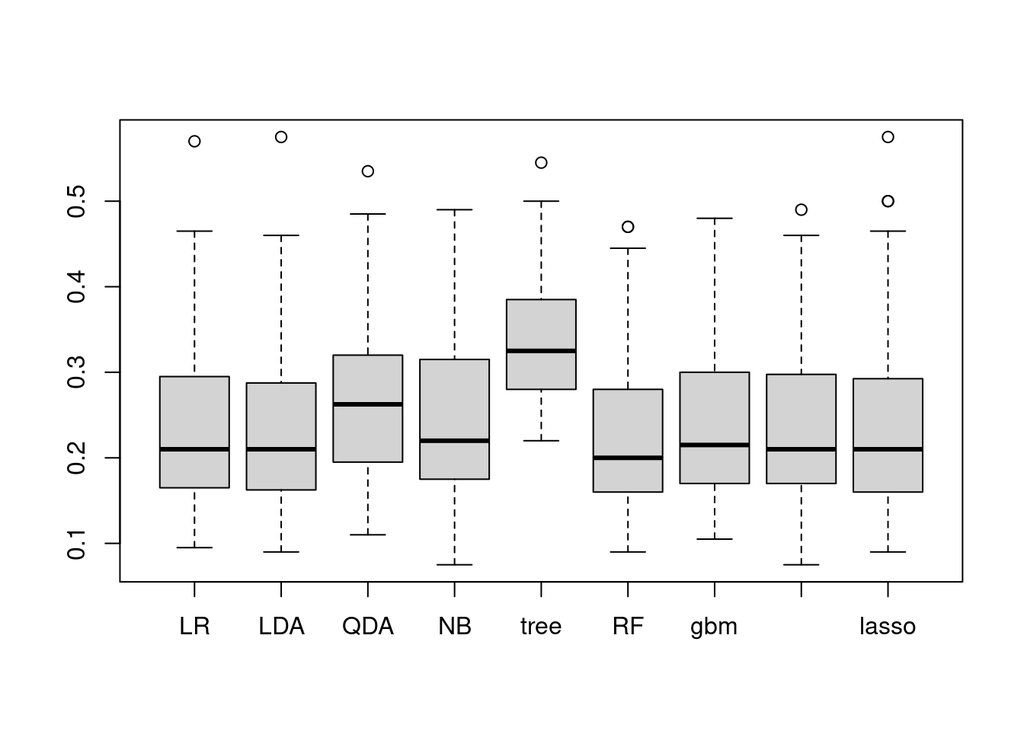

```r
# ======================== Problem 07 ==========================
# What need to apply
# 1. Draw a side-by-side boxplot where 9 methods are on the x-axis, CERs are on the y-axis
# 2. Find which method has the smallest mean/variance of the test CER?
RES <- cbind(CER1, CER2, CER3, CER4, CER5, CER6); colnames(RES) <- cbind("LR", "LDA", "QDA", "NB", "tree", "RF", "gbm", "adaboost", "lasso")
boxplot(RES)
```

```r
apply(RES, 2, mean)
```

```
##       LR      LDA      QDA       NB     tree       RF      gbm adaboost
##  0.23685  0.23380  0.26460  0.24925  0.34465  0.22275  0.24220  0.23865
##    lasso
##  0.23675
```

```r
apply(RES, 2, var)
```

```
##          LR         LDA         QDA          NB        tree          RF
## 0.009232149 0.009521778 0.008207414 0.009661301 0.006804674 0.007930492
##         gbm    adaboost       lasso
## 0.008499657 0.008472654 0.009907260
```